# R Notebook

```r
install.packages("tidycensus")
```

```
Error in install.packages : Updating loaded packages
```

```r
library(tidyverse)
library(janitor)
library(lubridate)
library(dplyr)
library(tidycensus)
```

```r
Clean_MD_Cases_By_County<-MD_COVID_19_Cases_by_County %>%
  clean_names()
```

```r
library(lubridate)
```

Was having a slight issue with my mutate, asked ChatGPT

```r
Clean_MD_Cases_By_County <- Clean_MD_Cases_By_County %>%
  mutate(date = mdy_hms(date) %>% date())
```

Let’s try to measure if we had a rise in November, specifically in the aftermath of Thanksgiving

```r
November_Cases_2023 <- Clean_MD_Cases_By_County %>%
  filter(year(date) == 2023, month(date) == 11)
```

```r
November_Cases_Mutate <-November_Cases_2023 %>%
  rowwise() %>%
  mutate(total_cases = sum(c_across(-c(objectid, date)),na.rm = TRUE))
```

Lets see if there’s a Thanksgiving rise:

November 27: 1414197, November 13: 1410997

There was only a .23% rise between Nov. 13 and Nov. 27, meaning the state scaved off a Thanksgiving spike

November 28: 1414663, November 1: 1408534

Cases rose .44% in Maryland in November. There was 6,129 more cases on Nov. 28 than on the first day of the month. There was a more than 3,200 case increase in that time.

```r
November_Cases_Mutate %>%
  mutate(Thanksgiving_Change = (1414197-1410997)/1410997*100)
```

| objectid | date | allegany | anne_arundel | baltimore | baltimore_city | calvert | caroline | carroll | cecil | charles | dorchester | frederick | garrett | harford | howard | kent | montgomery | prince_georges | queen_annes | somerset | st_marys | talbot | washington | wicomico | worcester | unknown | total_cases | Thanksgiving_Change |
| --- | --- | --- | --- | --- | --- | --- | --- | --- | --- | --- | --- | --- | --- | --- | --- | --- | --- | --- | --- | --- | --- | --- | --- | --- | --- | --- | --- | --- |
| 1327 | 2023-11-01 | 22625 | 123623 | 177382 | 153797 | 15268 | 7503 | 29006 | 21119 | 39811 | 9845 | 60029 | 7624 | 51693 | 67078 | 4066 | 254479 | 236800 | 9077 | 6340 | 25176 | 7505 | 41756 | 25687 | 11245 | 0 | 1408534 | 0.22679 |
| 1328 | 2023-11-02 | 22633 | 123638 | 177412 | 153814 | 15270 | 7505 | 29013 | 21123 | 39817 | 9847 | 60043 | 7628 | 51703 | 67096 | 4066 | 254517 | 236851 | 9079 | 6340 | 25178 | 7507 | 41758 | 25689 | 11245 | 0 | 1408772 | 0.22679 |
| 1329 | 2023-11-03 | 22645 | 123654 | 177447 | 153845 | 15270 | 7507 | 29016 | 21129 | 39823 | 9851 | 60054 | 7634 | 51713 | 67109 | 4067 | 254556 | 236875 | 9081 | 6340 | 25182 | 7508 | 41760 | 25692 | 11247 | 0 | 1409005 | 0.22679 |
| 1330 | 2023-11-04 | 22650 | 123673 | 177473 | 153874 | 15271 | 7509 | 29019 | 21136 | 39827 | 9858 | 60059 | 7638 | 51721 | 67124 | 4068 | 254592 | 236913 | 9082 | 6342 | 25182 | 7509 | 41764 | 25697 | 11247 | 0 | 1409228 | 0.22679 |
| 1331 | 2023-11-05 | 22654 | 123681 | 177489 | 153888 | 15271 | 7510 | 29024 | 21140 | 39829 | 9858 | 60068 | 7643 | 51724 | 67133 | 4068 | 254606 | 236935 | 9082 | 6342 | 25182 | 7513 | 41767 | 25698 | 11248 | 0 | 1409353 | 0.22679 |
| 1332 | 2023-11-06 | 22657 | 123689 | 177506 | 153900 | 15274 | 7510 | 29027 | 21140 | 39835 | 9858 | 60069 | 7643 | 51727 | 67141 | 4068 | 254624 | 236947 | 9083 | 6342 | 25184 | 7513 | 41767 | 25698 | 11249 | 0 | 1409451 | 0.22679 |
| 1333 | 2023-11-07 | 22667 | 123712 | 177547 | 153939 | 15274 | 7510 | 29030 | 21146 | 39840 | 9861 | 60085 | 7646 | 51740 | 67154 | 4070 | 254674 | 236982 | 9085 | 6343 | 25187 | 7516 | 41767 | 25704 | 11250 | 0 | 1409729 | 0.22679 |
| 1334 | 2023-11-08 | 22678 | 123718 | 177569 | 153965 | 15274 | 7512 | 29034 | 21148 | 39843 | 9864 | 60093 | 7651 | 51749 | 67166 | 4071 | 254696 | 237011 | 9085 | 6343 | 25189 | 7518 | 41772 | 25707 | 11253 | 0 | 1409909 | 0.22679 |
| 1335 | 2023-11-09 | 22683 | 123736 | 177607 | 154008 | 15274 | 7514 | 29040 | 21155 | 39848 | 9868 | 60104 | 7657 | 51763 | 67181 | 4072 | 254729 | 237039 | 9086 | 6344 | 25192 | 7519 | 41772 | 25709 | 11256 | 0 | 1410156 | 0.22679 |
| 1336 | 2023-11-10 | 22691 | 123759 | 177632 | 154052 | 15276 | 7517 | 29043 | 21161 | 39853 | 9870 | 60111 | 7661 | 51776 | 67191 | 4073 | 254785 | 237075 | 9088 | 6345 | 25194 | 7523 | 41775 | 25713 | 11257 | 0 | 1410421 | 0.22679 |

[output cut: 18 more lines]

```r
November_Cases_Mutate %>%
  mutate(November_Change= (1414663-1408534)/1408534*100)
```

| objectid | date | allegany | anne_arundel | baltimore | baltimore_city | calvert | caroline | carroll | cecil | charles | dorchester | frederick | garrett | harford | howard | kent | montgomery | prince_georges | queen_annes | somerset | st_marys | talbot | washington | wicomico | worcester | unknown | total_cases | November_Change |
| --- | --- | --- | --- | --- | --- | --- | --- | --- | --- | --- | --- | --- | --- | --- | --- | --- | --- | --- | --- | --- | --- | --- | --- | --- | --- | --- | --- | --- |
| 1327 | 2023-11-01 | 22625 | 123623 | 177382 | 153797 | 15268 | 7503 | 29006 | 21119 | 39811 | 9845 | 60029 | 7624 | 51693 | 67078 | 4066 | 254479 | 236800 | 9077 | 6340 | 25176 | 7505 | 41756 | 25687 | 11245 | 0 | 1408534 | 0.4351333 |
| 1328 | 2023-11-02 | 22633 | 123638 | 177412 | 153814 | 15270 | 7505 | 29013 | 21123 | 39817 | 9847 | 60043 | 7628 | 51703 | 67096 | 4066 | 254517 | 236851 | 9079 | 6340 | 25178 | 7507 | 41758 | 25689 | 11245 | 0 | 1408772 | 0.4351333 |
| 1329 | 2023-11-03 | 22645 | 123654 | 177447 | 153845 | 15270 | 7507 | 29016 | 21129 | 39823 | 9851 | 60054 | 7634 | 51713 | 67109 | 4067 | 254556 | 236875 | 9081 | 6340 | 25182 | 7508 | 41760 | 25692 | 11247 | 0 | 1409005 | 0.4351333 |
| 1330 | 2023-11-04 | 22650 | 123673 | 177473 | 153874 | 15271 | 7509 | 29019 | 21136 | 39827 | 9858 | 60059 | 7638 | 51721 | 67124 | 4068 | 254592 | 236913 | 9082 | 6342 | 25182 | 7509 | 41764 | 25697 | 11247 | 0 | 1409228 | 0.4351333 |
| 1331 | 2023-11-05 | 22654 | 123681 | 177489 | 153888 | 15271 | 7510 | 29024 | 21140 | 39829 | 9858 | 60068 | 7643 | 51724 | 67133 | 4068 | 254606 | 236935 | 9082 | 6342 | 25182 | 7513 | 41767 | 25698 | 11248 | 0 | 1409353 | 0.4351333 |
| 1332 | 2023-11-06 | 22657 | 123689 | 177506 | 153900 | 15274 | 7510 | 29027 | 21140 | 39835 | 9858 | 60069 | 7643 | 51727 | 67141 | 4068 | 254624 | 236947 | 9083 | 6342 | 25184 | 7513 | 41767 | 25698 | 11249 | 0 | 1409451 | 0.4351333 |
| 1333 | 2023-11-07 | 22667 | 123712 | 177547 | 153939 | 15274 | 7510 | 29030 | 21146 | 39840 | 9861 | 60085 | 7646 | 51740 | 67154 | 4070 | 254674 | 236982 | 9085 | 6343 | 25187 | 7516 | 41767 | 25704 | 11250 | 0 | 1409729 | 0.4351333 |
| 1334 | 2023-11-08 | 22678 | 123718 | 177569 | 153965 | 15274 | 7512 | 29034 | 21148 | 39843 | 9864 | 60093 | 7651 | 51749 | 67166 | 4071 | 254696 | 237011 | 9085 | 6343 | 25189 | 7518 | 41772 | 25707 | 11253 | 0 | 1409909 | 0.4351333 |
| 1335 | 2023-11-09 | 22683 | 123736 | 177607 | 154008 | 15274 | 7514 | 29040 | 21155 | 39848 | 9868 | 60104 | 7657 | 51763 | 67181 | 4072 | 254729 | 237039 | 9086 | 6344 | 25192 | 7519 | 41772 | 25709 | 11256 | 0 | 1410156 | 0.4351333 |
| 1336 | 2023-11-10 | 22691 | 123759 | 177632 | 154052 | 15276 | 7517 | 29043 | 21161 | 39853 | 9870 | 60111 | 7661 | 51776 | 67191 | 4073 | 254785 | 237075 | 9088 | 6345 | 25194 | 7523 | 41775 | 25713 | 11257 | 0 | 1410421 | 0.4351333 |

[output cut: 18 more lines]

```r
November_Cases_Difference <- November_Cases_Mutate %>%
  arrange(date)

November_Cases_Difference$diff <- c(NA, diff(November_Cases_Difference$total_cases))
```

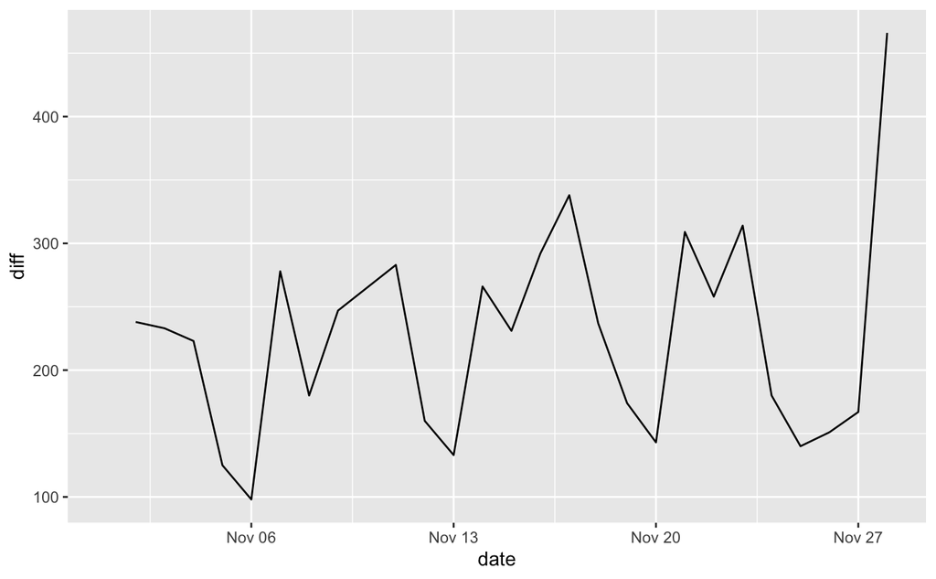

```r
November_Cases_Difference %>%
  ggplot() +
  geom_line(aes(x=date, y=diff))
```

Vaccination Rate by Population:

4/20/23 is the last day of that data

```r
MD_Vaccinations_By_County<-MD_COVID_19_Vaccinations_by_County %>%
  clean_names()
```

```r
MD_Vaccinations_By_County<-MD_Vaccinations_By_County %>%
  mutate(vaccination_date = mdy_hms(vaccination_date) %>% date())

MD_Vaccinations_By_County
```

| vaccination_date | county | first_dose_daily | first_dose_cumulative | second_dose_daily | second_dose_cumulative | single_dose_daily | single_dose_cumulative | fully_vaccinated | thirddosedaily | thirddosecumulative | firstboosterdailydose | additionaldosecumulative | fourthdailydose | secondadditionaldosecumulative | fullyvaccinatedcumulative |
| --- | --- | --- | --- | --- | --- | --- | --- | --- | --- | --- | --- | --- | --- | --- | --- |
| 2020-12-14 | Anne Arundel | 4 | 4 | NA | 0 | NA | 0 | NA | NA | 0 | NA | 0 | NA | 0 | 0 |
| 2020-12-14 | Baltimore | 2 | 2 | NA | 0 | NA | 0 | NA | NA | 0 | NA | 0 | NA | 0 | 0 |
| 2020-12-14 | Baltimore City | NA | 0 | 1 | 1 | NA | 0 | 1 | NA | 0 | NA | 0 | NA | 0 | 1 |
| 2020-12-14 | Carroll | 1 | 1 | NA | 0 | NA | 0 | NA | NA | 0 | NA | 0 | NA | 0 | 0 |
| 2020-12-14 | Frederick | 1 | 1 | 1 | 1 | NA | 0 | 1 | NA | 0 | NA | 0 | NA | 0 | 1 |
| 2020-12-14 | Howard | 5 | 5 | NA | 0 | NA | 0 | NA | NA | 0 | NA | 0 | NA | 0 | 0 |
| 2020-12-14 | Montgomery | 8 | 8 | NA | 0 | NA | 0 | NA | NA | 0 | NA | 0 | NA | 0 | 0 |
| 2020-12-14 | Prince Georges | 2 | 2 | NA | 0 | NA | 0 | NA | NA | 0 | NA | 0 | NA | 0 | 0 |
| 2020-12-14 | Unknown | 1 | 1 | NA | 0 | NA | 0 | NA | NA | 0 | NA | 0 | NA | 0 | 0 |
| 2020-12-14 | Wicomico | 1 | 1 | NA | 0 | NA | 0 | NA | NA | 0 | NA | 0 | NA | 0 | 0 |

[output cut: 990 more lines]

```r
April_20_2023_Vaccine <- MD_Vaccinations_By_County %>%
  filter(vaccination_date == as.Date("2023-04-20"))


April_20_2023_Vaccine
```

[output not shown]

There are three counties missing: Somerset, Garret and Dorchester, here’s how I’m creating a dataframe with those three counties. I will then join those datasets.

```r
Missing_County_Vaccine <- MD_Vaccinations_By_County %>%
  filter((county == "Somerset" & vaccination_date == as.Date("2023-04-19")) |
         (county == "Garrett" & vaccination_date == as.Date("2023-04-18")) |
         (county == "Dorchester" & vaccination_date == as.Date("2023-04-19")))

Missing_County_Vaccine
```

| vaccination_date | county | first_dose_daily | first_dose_cumulative | second_dose_daily | second_dose_cumulative | single_dose_daily | single_dose_cumulative | fully_vaccinated | thirddosedaily | thirddosecumulative | firstboosterdailydose | additionaldosecumulative | fourthdailydose | secondadditionaldosecumulative | fullyvaccinatedcumulative |
| --- | --- | --- | --- | --- | --- | --- | --- | --- | --- | --- | --- | --- | --- | --- | --- |
| 2023-04-18 | Garrett | NA | 14209 | 2 | 12996 | NA | 1077 | 2 | NA | 1 | 1 | 7992 | NA | 3501 | 14074 |
| 2023-04-19 | Dorchester | 1 | 18034 | NA | 16680 | NA | 2375 | NA | NA | 12 | NA | 10876 | NA | 5279 | 19067 |
| 2023-04-19 | Somerset | 1 | 12545 | NA | 11432 | NA | 1324 | NA | NA | 10 | 1 | 7065 | NA | 2606 | 12766 |

```r
Combined_Vaccine <- rbind(April_20_2023_Vaccine, Missing_County_Vaccine)
```

I combined these two rows to give me a table of county and percentage of people fully vaccinated.

```r
Fully_Vaccinated <- Combined_Vaccine %>%
  select(county, fullyvaccinatedcumulative)
```

```r
#census_api_key("549950d36c22ff16455fe196bbbd01d63cfbe6cf")
```

I grab population data to contextualize the rate of people vaccinated to the population.

```r
md_county_population <- get_acs(geography = "county",
              variables = c(population = "B01001_001"),
              year = 2021,
              state = "MD")
```

```r
md_county_population <-md_county_population %>%
  mutate(NAME = str_to_title(str_remove_all(NAME,"County, Maryland")))

md_county_population
```

| GEOID | NAME | variable | estimate | moe |
| --- | --- | --- | --- | --- |
| 24001 | Allegany | population | 68684 | NA |
| 24003 | Anne Arundel | population | 584064 | NA |
| 24005 | Baltimore | population | 850702 | NA |
| 24009 | Calvert | population | 92515 | NA |
| 24011 | Caroline | population | 33234 | NA |
| 24013 | Carroll | population | 172148 | NA |
| 24015 | Cecil | population | 103370 | NA |
| 24017 | Charles | population | 165209 | NA |
| 24019 | Dorchester | population | 32486 | NA |
| 24021 | Frederick | population | 267498 | NA |

[output cut: 14 more lines]

```r
md_county_population <-md_county_population %>%
  mutate(county = str_to_title(str_remove_all(county,", Maryland"))) %>%
  mutate(county = str_trim(county,side="both"))

md_county_population
```

[output not shown]

[output cut: 14 more lines]

```r
md_county_population<-md_county_population %>%
  rename(county=NAME)
```

[output not shown]

```r
md_county_population <- md_county_population %>%
  mutate(county = gsub("'", "", county))
```

Apostrophe’s were causing me 30 minutes of confusion, eventually realized and asked ChatGPT the most efficient way to remove them.

```r
County_Pop_Vaccinated <- md_county_population %>% left_join(Fully_Vaccinated)
```

```r
Population_Fully_Vaccinated<-County_Pop_Vaccinated %>%
  mutate(Pop_Fully_Vaccinated = fullyvaccinatedcumulative/estimate*100)

Population_Fully_Vaccinated
```

| GEOID | county | variable | estimate | moe | fullyvaccinatedcumulative | Pop_Fully_Vaccinated |
| --- | --- | --- | --- | --- | --- | --- |
| 24001 | Allegany | population | 68684 | NA | 36198 | 52.70223 |
| 24003 | Anne Arundel | population | 584064 | NA | 427919 | 73.26577 |
| 24005 | Baltimore | population | 850702 | NA | 613767 | 72.14830 |
| 24009 | Calvert | population | 92515 | NA | 65802 | 71.12576 |
| 24011 | Caroline | population | 33234 | NA | 18852 | 56.72504 |
| 24013 | Carroll | population | 172148 | NA | 121035 | 70.30869 |
| 24015 | Cecil | population | 103370 | NA | 55561 | 53.74964 |
| 24017 | Charles | population | 165209 | NA | 113055 | 68.43150 |
| 24019 | Dorchester | population | 32486 | NA | 19067 | 58.69298 |
| 24021 | Frederick | population | 267498 | NA | 207397 | 77.53217 |

[output cut: 14 more lines]

```r
write_csv(Population_Fully_Vaccinated,"Population_Fully_Vaccinated.csv")
```

```r
Probable_Deaths_By_County <- MD_COVID_19_Probable_Deaths_by_County %>%
  clean_names()
```

Map via Datawrapper: https://www.datawrapper.de/_/v98nt/

*Garrett County, most white dominant county has lowest full vaccination rate.* Montgomery County has more than 87% of its population vaccinated.

```r
Probable_Deaths_By_County <- MD_COVID_19_Probable_Deaths_by_County %>%
  clean_names()
```

```r
Probable_Deaths_By_County<-Probable_Deaths_By_County %>%
mutate(date = mdy_hms(date) %>% date())
```

Column formatting proved to be a major problem here. Having to establish numeric columns was a necessity. However, once I pivoted my goal to do this without objectid and date, it became significantly easier.

```r
numeric_columns <- setdiff(colnames(Probable_Deaths_By_County), c("County", "objectid"))
Probable_Deaths_By_County[numeric_columns] <- lapply(Probable_Deaths_By_County[numeric_columns], as.numeric)

Probable_Deaths_By_County
```

[output not shown]

I asked ChatGPT how to flip the dataframe to give me a two columns, one for total deaths per county and one for the county name.

```r
total_deaths_per_county <- data.frame(
  County = colnames(Probable_Deaths_By_County),
  Total_Deaths = colSums(Probable_Deaths_By_County, na.rm = TRUE)
)
```

```r
total_deaths_per_county <- total_deaths_per_county[!(total_deaths_per_county$County %in% c("objectid", "date")), ]
```

Names were originally messing up my join seen after this. I went county by county in ChatGPT and asked it to draw up code for a matching spelling to the population datafram to ensure the join had no reason to be off. Originally I was getting NAs on the total deaths column.

```r
library(dplyr)

# Replace the county names according to your specifications
total_deaths_per_county <- total_deaths_per_county %>%
  mutate(County = case_when(
    County == "allegany" ~ "Allegany",
    County == "anne_arundel" ~ "Anne Arundel",
    County == "baltimore" ~ "Baltimore",
    County == "baltimore_city" ~ "Baltimore City",
    County == "calvert" ~ "Calvert",
    County == "caroline" ~ "Caroline",
    County == "carroll" ~ "Carroll",
    County == "cecil" ~ "Cecil",
    County == "charles" ~ "Charles",
    County == "dorchester" ~ "Dorchester",
    County == "frederick" ~ "Frederick",
    County == "garrett" ~ "Garrett",
    County == "harford" ~ "Harford",
    County == "howard" ~ "Howard",
    County == "kent" ~ "Kent",
    County == "montgomery" ~ "Montgomery",
    County == "prince_georges" ~ "Prince Georges",
    County == "queen_annes" ~ "Queen Annes",
    County == "somerset" ~ "Somerset",
    County == "st_marys" ~ "St. Marys",
    County == "talbot" ~ "Talbot",
    County == "washington" ~ "Washington",
    County == "wiomico" ~ "Wiomico",
    County == "worcester" ~ "Worcester",
    TRUE ~ County
  ))

print(total_deaths_per_county)
```

[output not shown]

```r
total_deaths_per_county<-total_deaths_per_county %>%
  rename(county = County)
```

```r
Population_Death_Join <-md_county_population %>% left_join(total_deaths_per_county)
```

I decided to do per 10,000 people. Kent County has a low population total, therefore has a disproportionate amount of deaths. They are worth investigating, however due to the vaccination rates from before and how Montgomery County led, they may be the story here.

```r
 Population_Death_Join<-Population_Death_Join %>%
  mutate(Deaths_Per_10000 = Total_Deaths/estimate * 10000) %>%
  arrange(desc(Deaths_Per_10000))

Population_Death_Join
```

[output not shown]